# Ophiocoma orientation modelling according to binomial distribution

John Kirwan

11/2/2019

Load requisite packages.

```r
options(mc.cores = parallel::detectCores())
library('circular')
library('tibble')
library('readr')
library('tidyr')
library('dplyr')
library('ggplot2')
library('rstan')
Sys.setenv(LOCAL_CPPFLAGS = '-march=native')
rstan_options(auto_write = TRUE)
library('brms')
library(ggthemes)
theme_set(theme_tufte())
```

```r
sumlength <- function (x) { round(100* sum(x<0) / length(x),1) }
logistic  <- function (x) { p <- 1/(1 + exp(-x)); p <- ifelse(x == Inf, 1, p);   p }
logit     <- function (x) { log(x) - log(1 - x) }
```

The requisite part of pre-modelling markdown document is condensed below.

```r
df <- read_delim('Ophiocoma_orientation_data.txt',delim = "\t")
df <- subset.data.frame(df, Relative_heading_degrees != "DNF")
df$heading <- as.numeric(df$Relative_heading_degrees)*pi/180
df$heading[df$heading > pi] <- -pi +(df$heading[df$heading > pi] -pi)
df$Species <- as.factor(df$Species)
df$Type    <- as.factor(df$Type)
df$Set     <- as.factor(df$Set)
df <- subset.data.frame(df, select = -c(Absolute_heading_degrees,Relative_heading_degrees))
df$success   <- vector(length = length(df$heading))
sectors <- 5 # number of sectors, i.e. reciprocal of sector fraction
half.sector <- pi/sectors # half the width of the target sector
for(i in 1:length(df$heading)){           ### get tote of each using one fifth of the circle
  if(is.na(df$heading[i]) == TRUE){df$success[i] <- 0}
  else if(df$heading[i] >   half.sector ){df$success[i] <- 0}    ## pi/5 beforehand
  else if(df$heading[i] <= -half.sector ){df$success[i] <- 0}  ## -pi/5 beforehand
  else{df$success[i] <- 1}  }
df %>% filter(Set == 2017) -> df1
df1 <- droplevels.data.frame(df1)
df %>% filter(Set == 2019) -> df2
df2 <- droplevels.data.frame(df2)
```

# 2017 experiments with *Ophiocoma spp.*

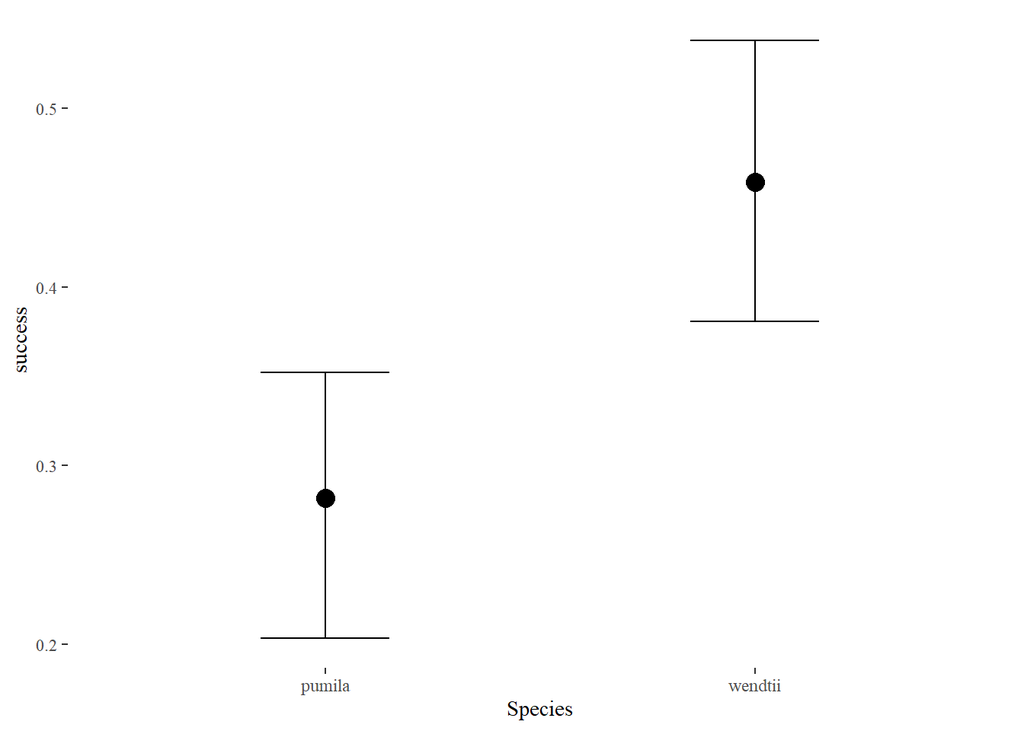

```r
Bin_Spp.formula <- bf(success ~ Species, family = bernoulli(link='logit'))
Bin_Spp.prior <- c(prior(normal(0, 2), class = "b"))

Bin_Spp.fit <- brm(Bin_Spp.formula,
               prior = Bin_Spp.prior, iter = 20000,
               data = df1, chains = 4,
               control = list(adapt_delta = 0.9))
Bin_Spp.fit <- add_criterion(Bin_Spp.fit, criterion=c('loo','waic'))

marginal_effects(Bin_Spp.fit, method = c("fitted"),
                 resolution = 1000, robust=TRUE,
                 theme=theme_classic(), nsamples = 1000, scale='response',
                                  re_formula = NULL,ask=F)
```

Posterior predictive check of counts.

```r
pp_check(Bin_Spp.fit, type="rootogram")
```

[output not shown]

```
## Using all posterior samples for ppc type 'rootogram' by default.
```

```r
Bin_Type.formula <- bf(success ~ Type, family = bernoulli(link='logit'))
Bin_Type.prior <- c(prior(normal(0, 2), class = "b"))

Bin_Type.fit <- brm(Bin_Type.formula,
               prior = Bin_Type.prior, iter = 20000,
               data = df1, chains = 4,
               control = list(adapt_delta = 0.9))
```

```
## recompiling to avoid crashing R session
```

```r
Bin_Type.fit <- add_criterion(Bin_Type.fit, criterion=c('loo','waic'))
```

The below plot indicates how orientation towards the stimulus differs for the three stimulus types, irrespective of the species.

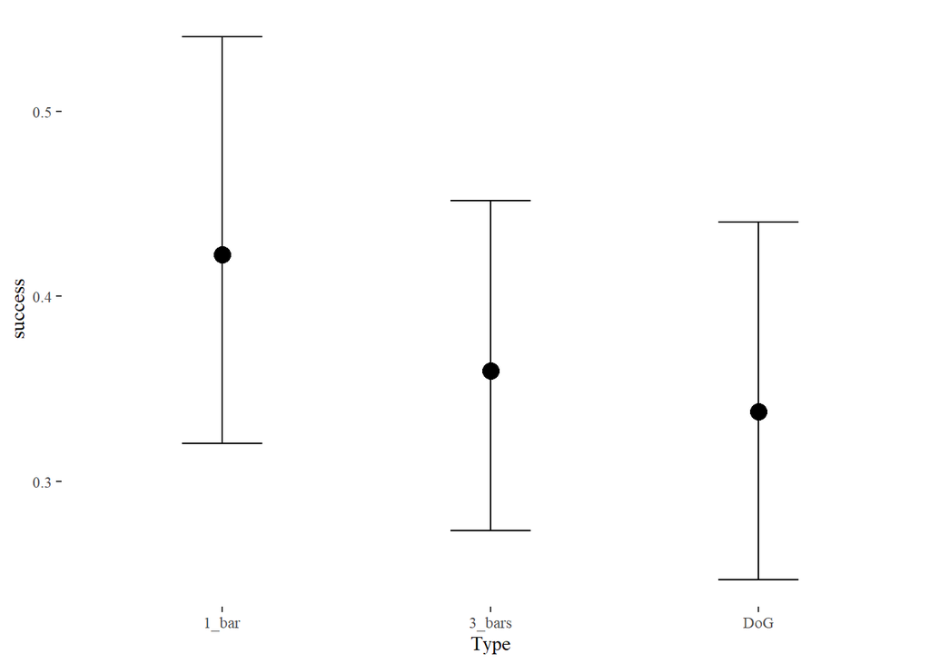

```r
marginal_effects(Bin_Type.fit, method = c("fitted"), resolution = 1000, robust=TRUE,
                 theme=theme_classic(), nsamples = 1000, scale='response',
                                  re_formula = NULL,ask=F)
```

Posterior predictive check of counts.

```r
pp_check(Bin_Type.fit, type="rootogram")
```

```
## Using all posterior samples for ppc type 'rootogram' by default.
```

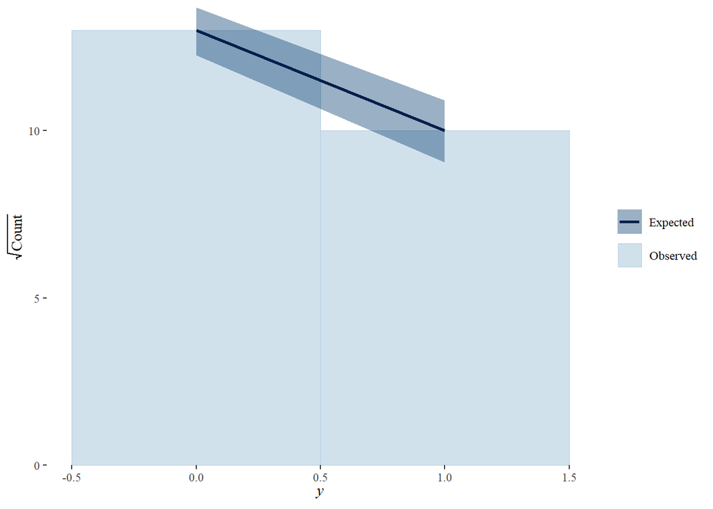

## Both Species and stimulus type

```r
Bin_Both.formula <- bf(success ~ Species+Type, family = bernoulli(link='logit'))
Bin_Both.prior <- c(prior(normal(0, 2), class = "b"))

Bin_Both.fit <- brm(Bin_Both.formula,
               prior = Bin_Both.prior, iter = 20000,
               data = df1, chains = 4,
               control = list(adapt_delta = 0.9))
```

```
## recompiling to avoid crashing R session
```

```r
Bin_Both.fit <- add_criterion(Bin_Both.fit, criterion=c('loo','waic'))
```

The plot below indicates the effect of species on orientation towards the stimulus, when the species and stimulus type are modelled together but not the interaction between them.

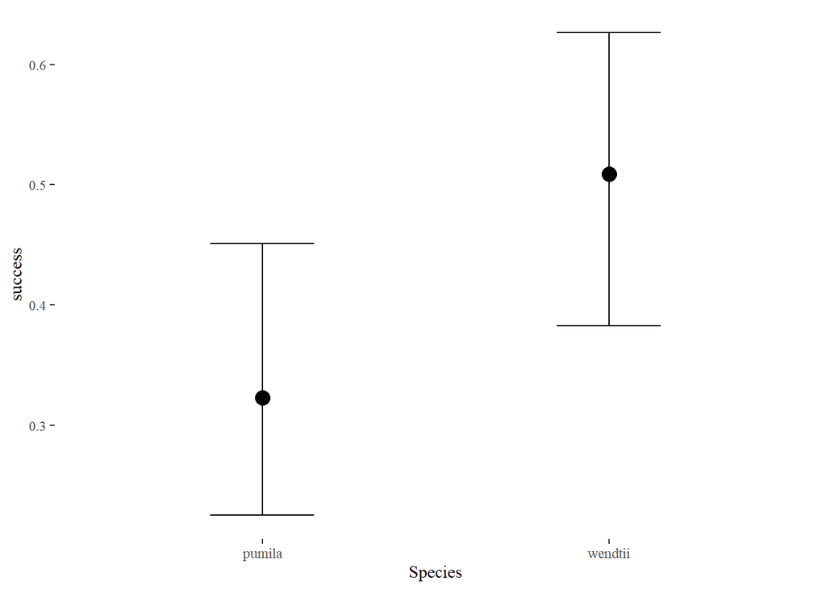

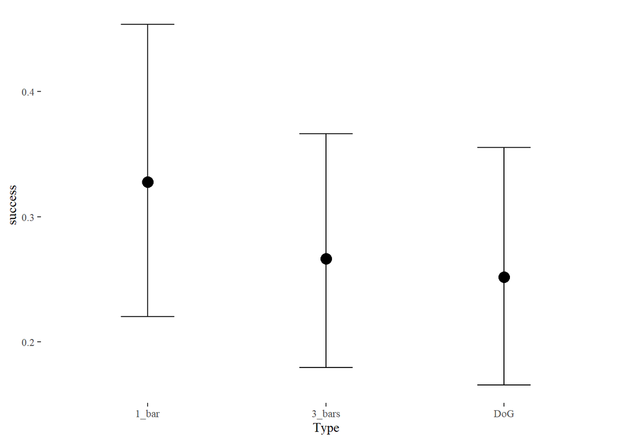

```r
marginal_effects(Bin_Both.fit, method = c("fitted"),
                 resolution = 1000, robust=TRUE,
                 theme=theme_classic(), nsamples = 1000,
                                  re_formula = NULL,ask=F)
```

Posterior predictive check of the count model, comparing expected counts to the data.

```r
pp_check(Bin_Both.fit, type="rootogram")
```

[output not shown]

```
## Using all posterior samples for ppc type 'rootogram' by default.
```

## Both Species and stimulus type with interaction

```r
Bin_Both_Interaction.formula <- bf(success ~ Species*Type, family = bernoulli(link='logit'))
Bin_Both_Interaction.prior <- c(prior(normal(0, 2), class = "b"))

Bin_Both_Interaction.fit <- brm(Bin_Both_Interaction.formula,
               prior = Bin_Both_Interaction.prior, iter = 20000,
               data = df1, chains = 4,
               control = list(adapt_delta = 0.99))
```

```
## recompiling to avoid crashing R session
```

```r
Bin_Both_Interaction.fit <- add_criterion(Bin_Both_Interaction.fit, criterion=c('loo','waic'))
summary(Bin_Both_Interaction.fit)
```

```
##  Family: bernoulli
##   Links: mu = logit
## Formula: success ~ Species * Type
##    Data: df1 (Number of observations: 269)
## Samples: 4 chains, each with iter = 20000; warmup = 10000; thin = 1;
##          total post-warmup samples = 40000
##
## Population-Level Effects:
##                           Estimate Est.Error l-95% CI u-95% CI Rhat
## Intercept                    -1.03      0.34    -1.71    -0.38 1.00
## Specieswendtii                1.37      0.44     0.53     2.24 1.00
## Type3_bars                    0.29      0.45    -0.59     1.16 1.00
## TypeDoG                      -0.11      0.47    -1.04     0.81 1.00
## Specieswendtii:Type3_bars    -1.09      0.59    -2.24     0.07 1.00
## Specieswendtii:TypeDoG       -0.54      0.62    -1.74     0.65 1.00
##                           Bulk_ESS Tail_ESS
## Intercept                    15935    20421
## Specieswendtii               14444    19941
## Type3_bars                   16282    22076
## TypeDoG                      16274    21726
## Specieswendtii:Type3_bars    14751    20998
## Specieswendtii:TypeDoG       15434    21412
##
## Samples were drawn using sampling(NUTS). For each parameter, Eff.Sample
## is a crude measure of effective sample size, and Rhat is the potential
## scale reduction factor on split chains (at convergence, Rhat = 1).
```

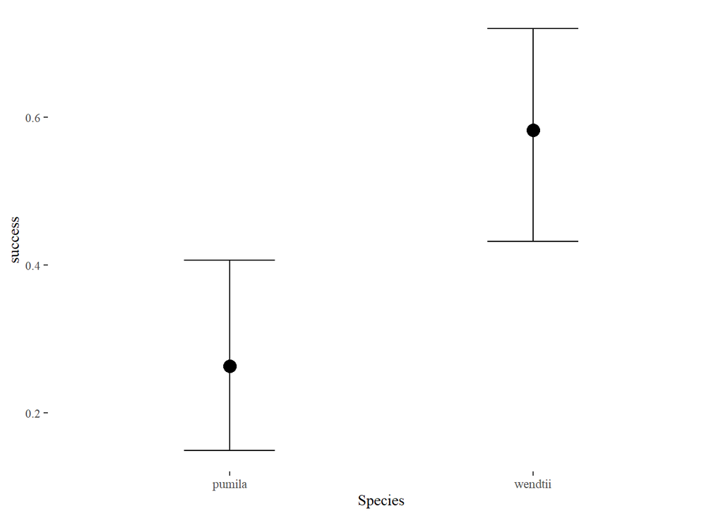

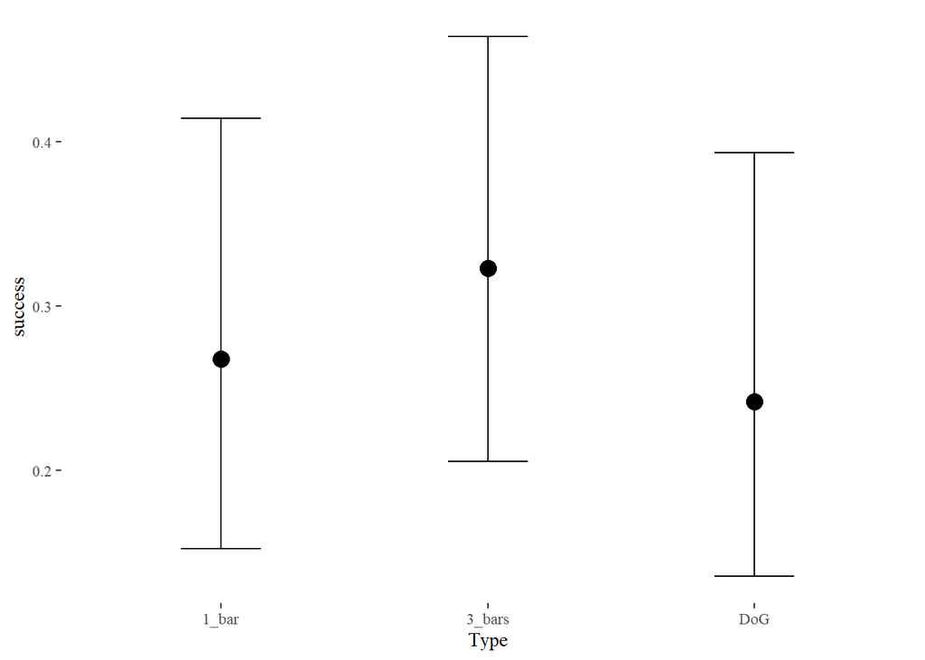

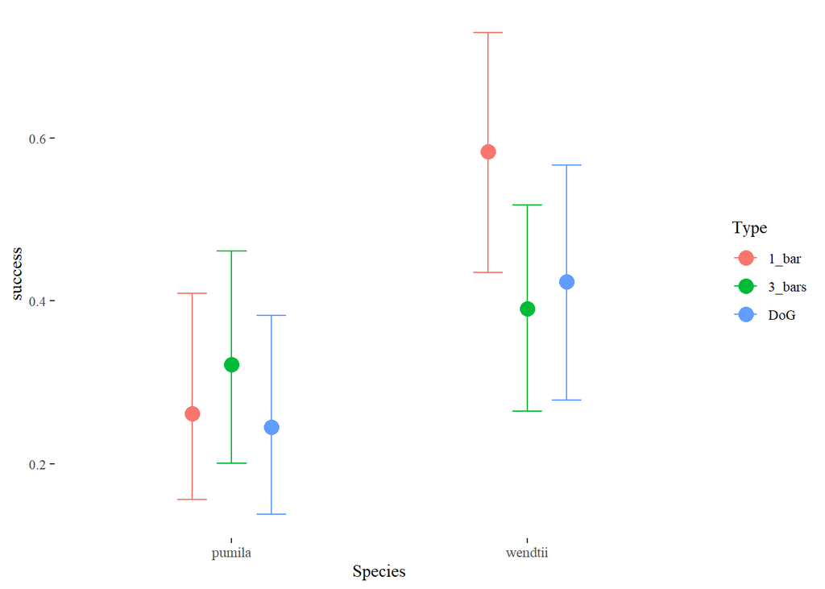

```r
marginal_effects(Bin_Both_Interaction.fit, method = c("fitted"),
                 resolution = 1000, robust=TRUE,
                 theme=theme_classic(), nsamples = 1000, scale='response',
                                  re_formula = NULL,ask=F)
```

Posterior predictive check of the count model, comparing expected counts to the data.

```r
pp_check(Bin_Both_Interaction.fit, type="rootogram")
```

[output not shown]

```
## Using all posterior samples for ppc type 'rootogram' by default.
```

Compare these discretized data models:

```r
loo_compare(Bin_Spp.fit,Bin_Type.fit,Bin_Both.fit,Bin_Both_Interaction.fit,criterion = 'waic')
```

```
##                          elpd_diff se_diff
## Bin_Spp.fit               0.0       0.0
## Bin_Both_Interaction.fit -1.2       2.2
## Bin_Both.fit             -1.2       1.2
## Bin_Type.fit             -5.0       3.2
```

```r
loo_compare(Bin_Spp.fit,Bin_Type.fit,Bin_Both.fit,Bin_Both_Interaction.fit,criterion=c("loo"))
```

```
##                          elpd_diff se_diff
## Bin_Spp.fit               0.0       0.0
## Bin_Both_Interaction.fit -1.2       2.2
## Bin_Both.fit             -1.2       1.2
## Bin_Type.fit             -5.0       3.2
```

```r
Bin_Both_Interaction.post <- posterior_samples(Bin_Both_Interaction.fit)
```

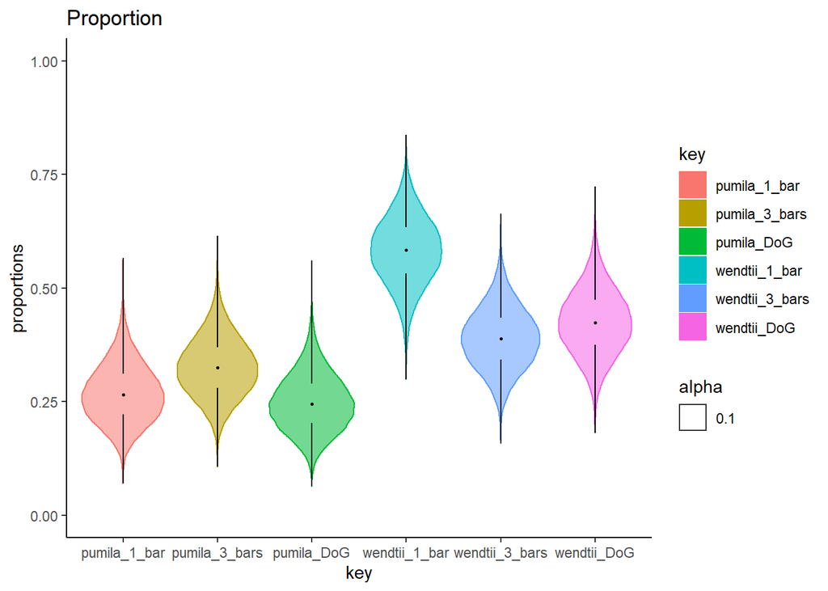

```r
pumila_1_bar     <- Bin_Both_Interaction.post$b_Intercept
pumila_3_bars    <- Bin_Both_Interaction.post$b_Intercept + Bin_Both_Interaction.post$b_Type3_bars
pumila_DoG       <- Bin_Both_Interaction.post$b_Intercept + Bin_Both_Interaction.post$b_TypeDoG
wendtii_1_bar    <- Bin_Both_Interaction.post$b_Intercept + Bin_Both_Interaction.post$b_Specieswendtii
wendtii_3_bars   <- Bin_Both_Interaction.post$b_Intercept + Bin_Both_Interaction.post$b_Specieswendtii +
                     Bin_Both_Interaction.post$b_Type3_bars + Bin_Both_Interaction.post$`b_Specieswendtii:Type3_bars`
wendtii_DoG     <-  Bin_Both_Interaction.post$b_Intercept + Bin_Both_Interaction.post$b_Specieswendtii +
                     Bin_Both_Interaction.post$b_TypeDoG + Bin_Both_Interaction.post$`b_Specieswendtii:TypeDoG`

vals <- as_tibble(cbind(pumila_1_bar,pumila_3_bars,pumila_DoG,wendtii_1_bar,wendtii_3_bars,wendtii_DoG))
vals <- gather(vals)

vals %>% mutate(value = logistic(value)) %>%
  ggplot(aes(key,value)) + geom_violin(aes(color=key,fill=key,alpha=0.1)) + geom_tufteboxplot()  +
  theme_classic() + ylim(0,1) + labs(title = "Proportion") + ylab('proportions')
```

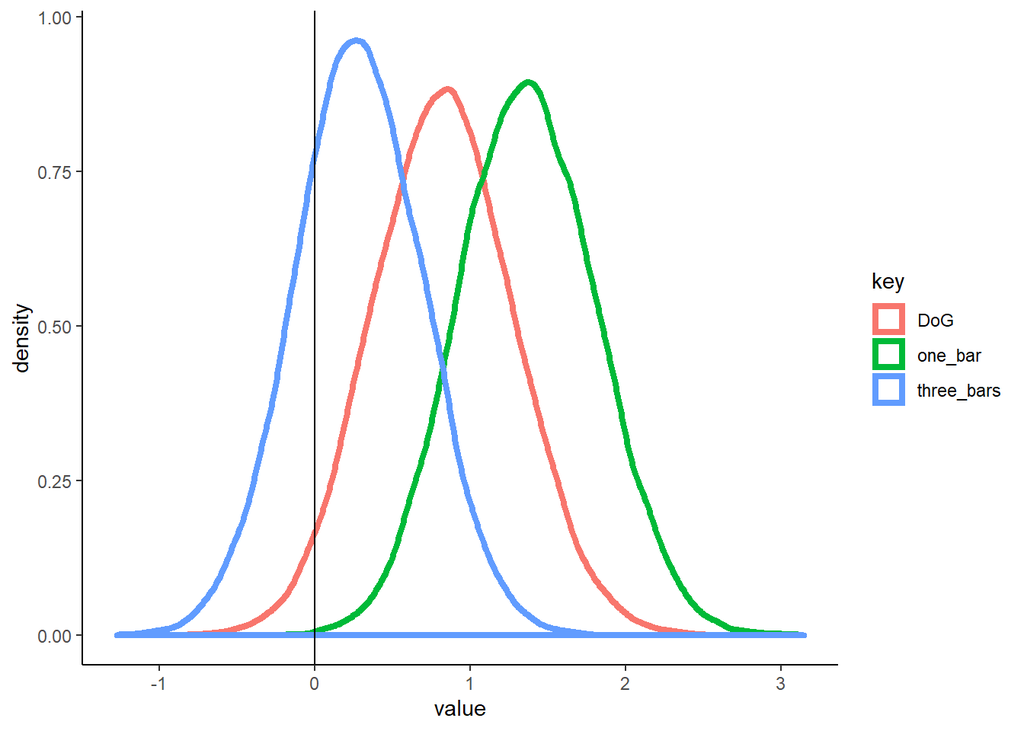

```r
one_bar     <- wendtii_1_bar - pumila_1_bar
three_bars  <- wendtii_3_bars - pumila_3_bars
DoG         <- wendtii_DoG - pumila_DoG

Spp_contrasts <- as_tibble(cbind(one_bar,three_bars,DoG))
Spp_contrasts <- gather(Spp_contrasts)

Spp_contrasts %>%
  ggplot(aes(x=value,group=key,colour=key)) +
  geom_density(size=1.5) + theme_classic() + geom_vline(xintercept = 0)
```

```r
Spp_contrasts %>% gather %>% group_by(key) %>%
  summarise(Percentage = sumlength(value)) -> Overlap
Overlap
```

```
## # A tibble: 3 x 2
##   key        Percentage
##   <chr>           <dbl>
## 1 DoG               3.2
## 2 one_bar           0
## 3 three_bars       24.6
```

The above plot contrasts the estimates between the two species at each of the stimulus types to find the probability that they have the same orientedness. This is enumerated below as percentages in the table.

The Spp. clearly differ for the single dark bar (Phototactic) and main experimental DoG (continuous visual) stimuli but not so for the 3 bars (discrete visual) stimulus.

The following code simulates random binomial data and then contrasts this with each of the treatments.

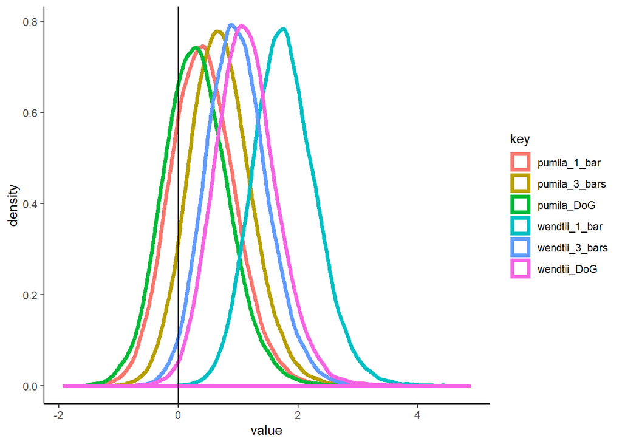

```r
set.seed(555)
data <- rbinom(40000,40,1/sectors)/40
logit.data <- logit(data)

pumila_1_bar     <- Bin_Both_Interaction.post$b_Intercept - logit.data
pumila_3_bars    <- Bin_Both_Interaction.post$b_Intercept +
                    Bin_Both_Interaction.post$b_Type3_bars - logit.data
pumila_DoG       <- Bin_Both_Interaction.post$b_Intercept +
                    Bin_Both_Interaction.post$b_TypeDoG - logit.data
wendtii_1_bar    <- Bin_Both_Interaction.post$b_Intercept +
                    Bin_Both_Interaction.post$b_Specieswendtii - logit.data
wendtii_3_bars   <- Bin_Both_Interaction.post$b_Intercept +
                    Bin_Both_Interaction.post$b_Specieswendtii +
                    Bin_Both_Interaction.post$b_Type3_bars +
                    Bin_Both_Interaction.post$`b_Specieswendtii:Type3_bars` - logit.data
wendtii_DoG     <-  Bin_Both_Interaction.post$b_Intercept + Bin_Both_Interaction.post$b_Specieswendtii +
                    Bin_Both_Interaction.post$b_TypeDoG +
                    Bin_Both_Interaction.post$`b_Specieswendtii:TypeDoG` - logit.data

control_contrasts <- as_tibble(cbind(
  pumila_1_bar,pumila_3_bars,pumila_DoG,wendtii_1_bar,wendtii_3_bars,wendtii_DoG))
control_contrasts <- gather(control_contrasts)

control_contrasts %>%
  ggplot(aes(x=value,group=key,colour=key)) +
  geom_density(size=1.5) + theme_classic() + geom_vline(xintercept = 0)
```

```r
control_contrasts %>% gather %>% group_by(key) %>%
  summarise(Percentage = sumlength(value)) -> Overlap
Overlap
```

```
## # A tibble: 6 x 2
##   key            Percentage
##   <chr>               <dbl>
## 1 pumila_1_bar         22.5
## 2 pumila_3_bars         8.1
## 3 pumila_DoG           29.7
## 4 wendtii_1_bar         0
## 5 wendtii_3_bars        2
## 6 wendtii_DoG           1
```

These (above) are the contrast with the simulated random data (assuming 40 observations per treatment). The percentage can be interpreted as the probability that the data is at or below the value expected by random chance.

# 2019 experiments with *Ophiocoma wendtii* in differing diel and light-adaptation conditions

```r
Bin_Diel.formula <- bf(success ~ Period_adaptation, family = bernoulli(link='logit'))
Bin_Diel.prior <- c(prior(normal(0, 2), class = "b"))

Bin_Diel.fit <- brm(Bin_Diel.formula,
               prior = Bin_Diel.prior, iter = 20000,
               data = df2, chains = 4,
               control = list(adapt_delta = 0.9))
```

```
## recompiling to avoid crashing R session
```

```r
Bin_Diel.fit <- add_criterion(Bin_Diel.fit, criterion=c('loo','waic'))
```

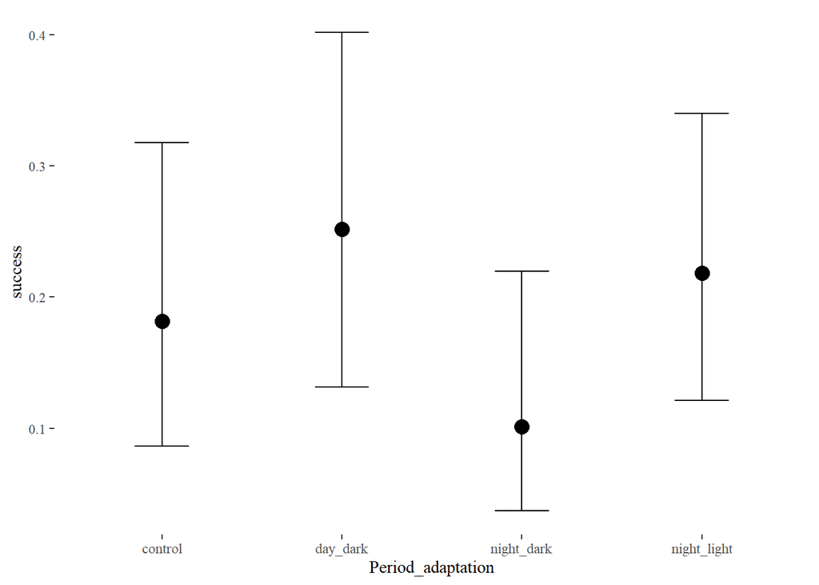

```r
marginal_effects(Bin_Diel.fit, method = c("fitted"), resolution = 1000, robust=TRUE,
                 theme=theme_classic(), nsamples = 1000,
                                  re_formula = NULL,ask=F)
```

```r
pp_check(Bin_Diel.fit, type="rootogram")
```

```
## Using all posterior samples for ppc type 'rootogram' by default.
```

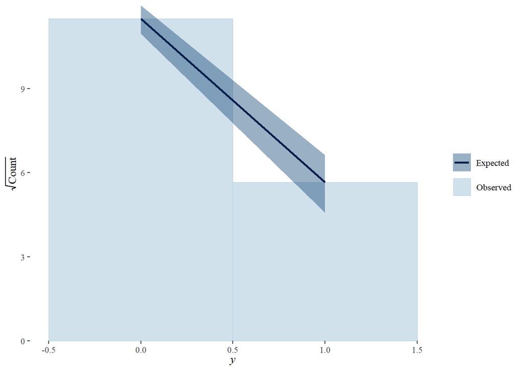

The marginal estimates at the median (of successful orientation for *O. wendtii* in differing diel and adaptive conditions) fall between 0.1 and 0.25, where the rate of success by random chance is 0.2, incidating the animals are disoriented. They are in the range of estimates for the earlier *O. pumila* treatments but not those of *O. wendtii* with the earlier bar (phototactic) and DoG (continuous visual) conditions.

The following contrasts the treatments with the control data.

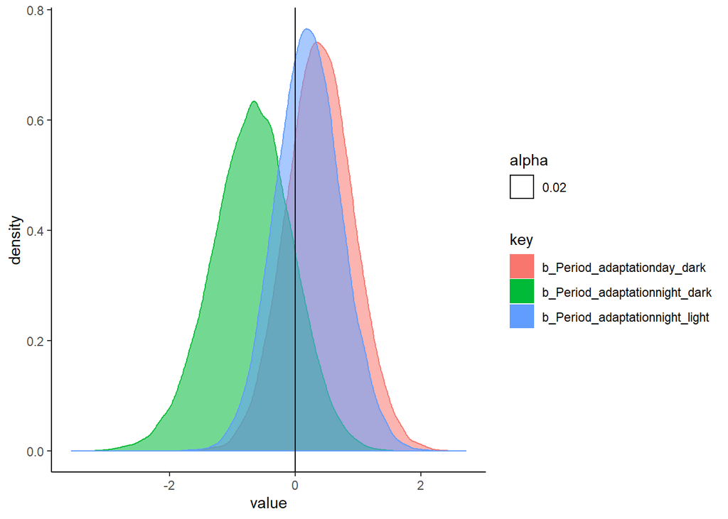

```r
Bin_Diel.post <- as_tibble(posterior_samples(Bin_Diel.fit))

Bin_Diel.post %>% select(-lp__,-b_Intercept) %>% gather %>%
  ggplot(aes(x=value,group=key,colour=key,fill=key,alpha=0.02)) +
  geom_density() + theme_classic() + geom_vline(xintercept = 0)
```

These (below) are the contrast with the control data. The percentage can be interpreted as the probability that the data is at or below what would be expected by random chance.

```r
Bin_Diel.post %>%  select(-lp__,-b_Intercept) %>%
  gather %>% group_by(key) %>%
  summarise(Percentage = sumlength(value)) -> Overlap
Overlap
```

```
## # A tibble: 3 x 2
##   key                            Percentage
##   <chr>                               <dbl>
## 1 b_Period_adaptationday_dark          23.1
## 2 b_Period_adaptationnight_dark        86
## 3 b_Period_adaptationnight_light       34.8
```

There is considerable overlap between these data and the control data and one treatment, the dark-adapted animals tested at night (Night_dark) is more uniform.

We conclude given the estimates of successful orientation for each and their contrasts with the control that none of these treatments are oriented.